# Risk Factor Analysis

## Outcome Variable

**Outcome Variable:** stunted

## Predictor Variables

**Intervention Variable:** nchldlt5

**Adjustment Set:**

- arm
- W_mage
- meducyrs
- feducyrs
- hhwealth_quart
- hfoodsec
- W_mhtcm
- W_nrooms
- W_parity
- impfloor
- impsan
- safeh20
- delta_W_mage
- delta_meducyrs
- delta_feducyrs
- delta_hhwealth_quart
- delta_hfoodsec
- delta_W_mhtcm
- delta_W_nrooms
- delta_W_parity
- delta_impfloor
- delta_impsan
- delta_safeh20

## Stratifying Variables

The analysis was stratified on these variable(s):

- agecat
- studyid
- country

## Data Summary

| agecat | studyid | country | nchldlt5 | stunted | n_cell | n |
| --- | --- | --- | --- | --- | --- | --- |
| Birth | ki1000108-IRC | INDIA | 1 | 0 | 72 | 274 |
| Birth | ki1000108-IRC | INDIA | 1 | 1 | 12 | 274 |
| Birth | ki1000108-IRC | INDIA | 2+ | 0 | 171 | 274 |
| Birth | ki1000108-IRC | INDIA | 2+ | 1 | 19 | 274 |
| Birth | ki1017093c-NIH-Crypto | BANGLADESH | 1 | 0 | 14 | 19 |
| Birth | ki1017093c-NIH-Crypto | BANGLADESH | 1 | 1 | 4 | 19 |
| Birth | ki1017093c-NIH-Crypto | BANGLADESH | 2+ | 0 | 1 | 19 |
| Birth | ki1017093c-NIH-Crypto | BANGLADESH | 2+ | 1 | 0 | 19 |
| Birth | kiGH5241-JiVitA-3 | BANGLADESH | 1 | 0 | 15730 | 25142 |
| Birth | kiGH5241-JiVitA-3 | BANGLADESH | 1 | 1 | 8478 | 25142 |
| Birth | kiGH5241-JiVitA-3 | BANGLADESH | 2+ | 0 | 690 | 25142 |
| Birth | kiGH5241-JiVitA-3 | BANGLADESH | 2+ | 1 | 244 | 25142 |
| 6 months | ki1000108-IRC | INDIA | 1 | 0 | 67 | 288 |
| 6 months | ki1000108-IRC | INDIA | 1 | 1 | 22 | 288 |
| 6 months | ki1000108-IRC | INDIA | 2+ | 0 | 150 | 288 |
| 6 months | ki1000108-IRC | INDIA | 2+ | 1 | 49 | 288 |
| 6 months | ki1017093b-PROVIDE | BANGLADESH | 1 | 0 | 357 | 435 |
| 6 months | ki1017093b-PROVIDE | BANGLADESH | 1 | 1 | 69 | 435 |
| 6 months | ki1017093b-PROVIDE | BANGLADESH | 2+ | 0 | 8 | 435 |
| 6 months | ki1017093b-PROVIDE | BANGLADESH | 2+ | 1 | 1 | 435 |
| 6 months | ki1017093c-NIH-Crypto | BANGLADESH | 1 | 0 | 400 | 512 |
| 6 months | ki1017093c-NIH-Crypto | BANGLADESH | 1 | 1 | 107 | 512 |
| 6 months | ki1017093c-NIH-Crypto | BANGLADESH | 2+ | 0 | 5 | 512 |
| 6 months | ki1017093c-NIH-Crypto | BANGLADESH | 2+ | 1 | 0 | 512 |
| 6 months | ki1066203-TanzaniaChild2 | TANZANIA, UNITED REPUBLIC OF | 1 | 0 | 1267 | 1453 |
| 6 months | ki1066203-TanzaniaChild2 | TANZANIA, UNITED REPUBLIC OF | 1 | 1 | 124 | 1453 |
| 6 months | ki1066203-TanzaniaChild2 | TANZANIA, UNITED REPUBLIC OF | 2+ | 0 | 55 | 1453 |
| 6 months | ki1066203-TanzaniaChild2 | TANZANIA, UNITED REPUBLIC OF | 2+ | 1 | 7 | 1453 |
| 6 months | ki1148112-LCNI-5 | MALAWI | 1 | 0 | 263 | 453 |
| 6 months | ki1148112-LCNI-5 | MALAWI | 1 | 1 | 127 | 453 |
| 6 months | ki1148112-LCNI-5 | MALAWI | 2+ | 0 | 37 | 453 |
| 6 months | ki1148112-LCNI-5 | MALAWI | 2+ | 1 | 26 | 453 |
| 6 months | kiGH5241-JiVitA-3 | BANGLADESH | 1 | 0 | 16158 | 22466 |
| 6 months | kiGH5241-JiVitA-3 | BANGLADESH | 1 | 1 | 5579 | 22466 |
| 6 months | kiGH5241-JiVitA-3 | BANGLADESH | 2+ | 0 | 543 | 22466 |
| 6 months | kiGH5241-JiVitA-3 | BANGLADESH | 2+ | 1 | 186 | 22466 |
| 24 months | ki1000108-IRC | INDIA | 1 | 0 | 58 | 290 |
| 24 months | ki1000108-IRC | INDIA | 1 | 1 | 31 | 290 |
| 24 months | ki1000108-IRC | INDIA | 2+ | 0 | 108 | 290 |
| 24 months | ki1000108-IRC | INDIA | 2+ | 1 | 93 | 290 |
| 24 months | ki1017093b-PROVIDE | BANGLADESH | 1 | 0 | 298 | 431 |
| 24 months | ki1017093b-PROVIDE | BANGLADESH | 1 | 1 | 125 | 431 |
| 24 months | ki1017093b-PROVIDE | BANGLADESH | 2+ | 0 | 6 | 431 |
| 24 months | ki1017093b-PROVIDE | BANGLADESH | 2+ | 1 | 2 | 431 |
| 24 months | ki1017093c-NIH-Crypto | BANGLADESH | 1 | 0 | 276 | 361 |
| 24 months | ki1017093c-NIH-Crypto | BANGLADESH | 1 | 1 | 81 | 361 |
| 24 months | ki1017093c-NIH-Crypto | BANGLADESH | 2+ | 0 | 3 | 361 |
| 24 months | ki1017093c-NIH-Crypto | BANGLADESH | 2+ | 1 | 1 | 361 |
| 24 months | ki1066203-TanzaniaChild2 | TANZANIA, UNITED REPUBLIC OF | 1 | 0 | 4 | 5 |
| 24 months | ki1066203-TanzaniaChild2 | TANZANIA, UNITED REPUBLIC OF | 1 | 1 | 1 | 5 |
| 24 months | ki1066203-TanzaniaChild2 | TANZANIA, UNITED REPUBLIC OF | 2+ | 0 | 0 | 5 |
| 24 months | ki1066203-TanzaniaChild2 | TANZANIA, UNITED REPUBLIC OF | 2+ | 1 | 0 | 5 |
| 24 months | ki1148112-LCNI-5 | MALAWI | 1 | 0 | 163 | 327 |
| 24 months | ki1148112-LCNI-5 | MALAWI | 1 | 1 | 120 | 327 |
| 24 months | ki1148112-LCNI-5 | MALAWI | 2+ | 0 | 21 | 327 |
| 24 months | ki1148112-LCNI-5 | MALAWI | 2+ | 1 | 23 | 327 |
| 24 months | kiGH5241-JiVitA-3 | BANGLADESH | 1 | 0 | 5771 | 11320 |
| 24 months | kiGH5241-JiVitA-3 | BANGLADESH | 1 | 1 | 5112 | 11320 |
| 24 months | kiGH5241-JiVitA-3 | BANGLADESH | 2+ | 0 | 195 | 11320 |
| 24 months | kiGH5241-JiVitA-3 | BANGLADESH | 2+ | 1 | 242 | 11320 |

The following strata were considered:

- agecat: 24 months, studyid: ki1000108-IRC, country: INDIA
- agecat: 24 months, studyid: ki1017093b-PROVIDE, country: BANGLADESH
- agecat: 24 months, studyid: ki1017093c-NIH-Crypto, country: BANGLADESH
- agecat: 24 months, studyid: ki1066203-TanzaniaChild2, country: TANZANIA, UNITED REPUBLIC OF
- agecat: 24 months, studyid: ki1148112-LCNI-5, country: MALAWI
- agecat: 24 months, studyid: kiGH5241-JiVitA-3, country: BANGLADESH
- agecat: 6 months, studyid: ki1000108-IRC, country: INDIA
- agecat: 6 months, studyid: ki1017093b-PROVIDE, country: BANGLADESH
- agecat: 6 months, studyid: ki1017093c-NIH-Crypto, country: BANGLADESH
- agecat: 6 months, studyid: ki1066203-TanzaniaChild2, country: TANZANIA, UNITED REPUBLIC OF
- agecat: 6 months, studyid: ki1148112-LCNI-5, country: MALAWI
- agecat: 6 months, studyid: kiGH5241-JiVitA-3, country: BANGLADESH
- agecat: Birth, studyid: ki1000108-IRC, country: INDIA
- agecat: Birth, studyid: ki1017093c-NIH-Crypto, country: BANGLADESH
- agecat: Birth, studyid: kiGH5241-JiVitA-3, country: BANGLADESH

### Dropped Strata

Some strata were dropped due to rare outcomes:

- agecat: Birth, studyid: ki1017093c-NIH-Crypto, country: BANGLADESH
- agecat: 6 months, studyid: ki1017093b-PROVIDE, country: BANGLADESH
- agecat: 6 months, studyid: ki1017093c-NIH-Crypto, country: BANGLADESH
- agecat: 24 months, studyid: ki1017093b-PROVIDE, country: BANGLADESH
- agecat: 24 months, studyid: ki1017093c-NIH-Crypto, country: BANGLADESH
- agecat: 24 months, studyid: ki1066203-TanzaniaChild2, country: TANZANIA, UNITED REPUBLIC OF

## Methods Detail

We’re interested in the causal parameters $E[Y_a]$ for all values of $a \in \mathcal{A}$. These parameters represent the mean outcome if, possibly contrary to fact, we intervened to set all units to have $A=a$. Under the randomization and positivity assumptions, these are identified by the statistical parameters $\psi_a=E_W[E_{Y|A,W}(Y|A=a,W)]$. In addition, we’re interested in the mean of $Y$, $E[Y]$ under no intervention (the observed mean). We will estimate these parameters by using SuperLearner to fit the relevant likelihood factors – $E_{Y|A,W}(Y|A=a,W)$ and $p(A=a|W)$, and then updating our likelihood fit using a joint TMLE.

For unadjusted analyses ($W=\{\}$), initial likelihoods were estimated using Lrnr_glm to estimate the simple $E(Y|A)$ and Lrnr_mean to estimate $p(A)$. For adjusted analyses, a small library containing Lrnr_glmnet, Lrnr_xgboost, and Lrnr_mean was used.

Having estimated these parameters, we will then use the delta method to estimate relative risks and attributable risks relative to a prespecified baseline level of $A$.

# Results Detail

## Results Plots

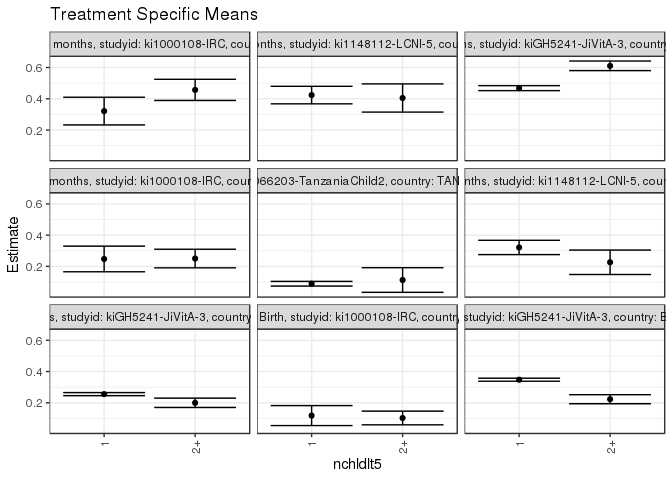

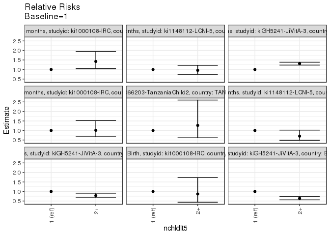

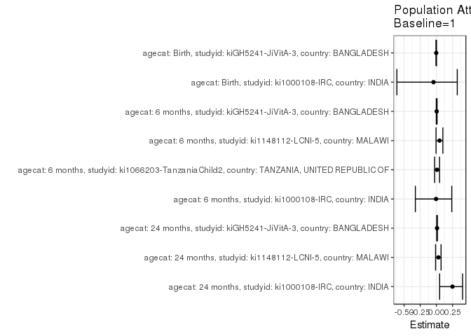

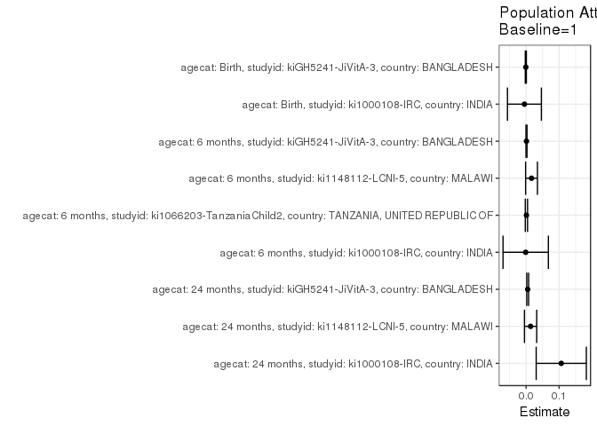

## Results Table

### Parameter: TSM

| agecat | studyid | country | intervention_level | baseline_level | estimate | ci_lower | ci_upper |
| --- | --- | --- | --- | --- | --- | --- | --- |
| Birth | ki1000108-IRC | INDIA | 1 | NA | 0.1181276 | 0.0541522 | 0.1821031 |
| Birth | ki1000108-IRC | INDIA | 2+ | NA | 0.1027331 | 0.0588525 | 0.1466136 |
| Birth | kiGH5241-JiVitA-3 | BANGLADESH | 1 | NA | 0.3476913 | 0.3380481 | 0.3573345 |
| Birth | kiGH5241-JiVitA-3 | BANGLADESH | 2+ | NA | 0.2230009 | 0.1940754 | 0.2519263 |
| 6 months | ki1000108-IRC | INDIA | 1 | NA | 0.2476772 | 0.1656190 | 0.3297353 |
| 6 months | ki1000108-IRC | INDIA | 2+ | NA | 0.2502770 | 0.1907822 | 0.3097718 |
| 6 months | ki1066203-TanzaniaChild2 | TANZANIA, UNITED REPUBLIC OF | 1 | NA | 0.0891445 | 0.0741647 | 0.1041243 |
| 6 months | ki1066203-TanzaniaChild2 | TANZANIA, UNITED REPUBLIC OF | 2+ | NA | 0.1129032 | 0.0341006 | 0.1917058 |
| 6 months | ki1148112-LCNI-5 | MALAWI | 1 | NA | 0.3212877 | 0.2756243 | 0.3669511 |
| 6 months | ki1148112-LCNI-5 | MALAWI | 2+ | NA | 0.2264309 | 0.1483155 | 0.3045463 |
| 6 months | kiGH5241-JiVitA-3 | BANGLADESH | 1 | NA | 0.2553999 | 0.2455663 | 0.2652335 |
| 6 months | kiGH5241-JiVitA-3 | BANGLADESH | 2+ | NA | 0.2000082 | 0.1701675 | 0.2298489 |
| 24 months | ki1000108-IRC | INDIA | 1 | NA | 0.3211324 | 0.2325751 | 0.4096896 |
| 24 months | ki1000108-IRC | INDIA | 2+ | NA | 0.4568449 | 0.3891842 | 0.5245056 |
| 24 months | ki1148112-LCNI-5 | MALAWI | 1 | NA | 0.4237125 | 0.3675723 | 0.4798526 |
| 24 months | ki1148112-LCNI-5 | MALAWI | 2+ | NA | 0.4049792 | 0.3147773 | 0.4951811 |
| 24 months | kiGH5241-JiVitA-3 | BANGLADESH | 1 | NA | 0.4681089 | 0.4520521 | 0.4841656 |
| 24 months | kiGH5241-JiVitA-3 | BANGLADESH | 2+ | NA | 0.6107859 | 0.5801943 | 0.6413775 |

### Parameter: E(Y)

| agecat | studyid | country | intervention_level | baseline_level | estimate | ci_lower | ci_upper |
| --- | --- | --- | --- | --- | --- | --- | --- |
| Birth | ki1000108-IRC | INDIA | NA | NA | 0.1131387 | 0.0755636 | 0.1507138 |
| Birth | kiGH5241-JiVitA-3 | BANGLADESH | NA | NA | 0.3469096 | 0.3373971 | 0.3564220 |
| 6 months | ki1000108-IRC | INDIA | NA | NA | 0.2465278 | 0.1966653 | 0.2963902 |
| 6 months | ki1066203-TanzaniaChild2 | TANZANIA, UNITED REPUBLIC OF | NA | NA | 0.0901583 | 0.0754267 | 0.1048899 |
| 6 months | ki1148112-LCNI-5 | MALAWI | NA | NA | 0.3377483 | 0.2941483 | 0.3813484 |
| 6 months | kiGH5241-JiVitA-3 | BANGLADESH | NA | NA | 0.2566100 | 0.2468432 | 0.2663768 |
| 24 months | ki1000108-IRC | INDIA | NA | NA | 0.4275862 | 0.3705480 | 0.4846244 |
| 24 months | ki1148112-LCNI-5 | MALAWI | NA | NA | 0.4373089 | 0.3834610 | 0.4911567 |
| 24 months | kiGH5241-JiVitA-3 | BANGLADESH | NA | NA | 0.4729682 | 0.4569445 | 0.4889919 |

### Parameter: RR

| agecat | studyid | country | intervention_level | baseline_level | estimate | ci_lower | ci_upper |
| --- | --- | --- | --- | --- | --- | --- | --- |
| Birth | ki1000108-IRC | INDIA | 1 | 1 | 1.0000000 | 1.0000000 | 1.0000000 |
| Birth | ki1000108-IRC | INDIA | 2+ | 1 | 0.8696786 | 0.4367706 | 1.7316662 |
| Birth | kiGH5241-JiVitA-3 | BANGLADESH | 1 | 1 | 1.0000000 | 1.0000000 | 1.0000000 |
| Birth | kiGH5241-JiVitA-3 | BANGLADESH | 2+ | 1 | 0.6413760 | 0.5622898 | 0.7315856 |
| 6 months | ki1000108-IRC | INDIA | 1 | 1 | 1.0000000 | 1.0000000 | 1.0000000 |
| 6 months | ki1000108-IRC | INDIA | 2+ | 1 | 1.0104968 | 0.6720312 | 1.5194293 |
| 6 months | ki1066203-TanzaniaChild2 | TANZANIA, UNITED REPUBLIC OF | 1 | 1 | 1.0000000 | 1.0000000 | 1.0000000 |
| 6 months | ki1066203-TanzaniaChild2 | TANZANIA, UNITED REPUBLIC OF | 2+ | 1 | 1.2665193 | 0.6177715 | 2.5965442 |
| 6 months | ki1148112-LCNI-5 | MALAWI | 1 | 1 | 1.0000000 | 1.0000000 | 1.0000000 |
| 6 months | ki1148112-LCNI-5 | MALAWI | 2+ | 1 | 0.7047607 | 0.4871096 | 1.0196631 |
| 6 months | kiGH5241-JiVitA-3 | BANGLADESH | 1 | 1 | 1.0000000 | 1.0000000 | 1.0000000 |
| 6 months | kiGH5241-JiVitA-3 | BANGLADESH | 2+ | 1 | 0.7831178 | 0.6732084 | 0.9109711 |
| 24 months | ki1000108-IRC | INDIA | 1 | 1 | 1.0000000 | 1.0000000 | 1.0000000 |
| 24 months | ki1000108-IRC | INDIA | 2+ | 1 | 1.4226063 | 1.0416893 | 1.9428140 |
| 24 months | ki1148112-LCNI-5 | MALAWI | 1 | 1 | 1.0000000 | 1.0000000 | 1.0000000 |
| 24 months | ki1148112-LCNI-5 | MALAWI | 2+ | 1 | 0.9557878 | 0.7481853 | 1.2209948 |
| 24 months | kiGH5241-JiVitA-3 | BANGLADESH | 1 | 1 | 1.0000000 | 1.0000000 | 1.0000000 |
| 24 months | kiGH5241-JiVitA-3 | BANGLADESH | 2+ | 1 | 1.3047945 | 1.2311602 | 1.3828329 |

### Parameter: PAR

| agecat | studyid | country | intervention_level | baseline_level | estimate | ci_lower | ci_upper |
| --- | --- | --- | --- | --- | --- | --- | --- |
| Birth | ki1000108-IRC | INDIA | 1 | NA | -0.0049889 | -0.0562928 | 0.0463150 |
| Birth | kiGH5241-JiVitA-3 | BANGLADESH | 1 | NA | -0.0007817 | -0.0023596 | 0.0007961 |
| 6 months | ki1000108-IRC | INDIA | 1 | NA | -0.0011494 | -0.0697713 | 0.0674725 |
| 6 months | ki1066203-TanzaniaChild2 | TANZANIA, UNITED REPUBLIC OF | 1 | NA | 0.0010138 | -0.0024179 | 0.0044454 |
| 6 months | ki1148112-LCNI-5 | MALAWI | 1 | NA | 0.0164607 | -0.0014041 | 0.0343254 |
| 6 months | kiGH5241-JiVitA-3 | BANGLADESH | 1 | NA | 0.0012101 | -0.0003052 | 0.0027254 |
| 24 months | ki1000108-IRC | INDIA | 1 | NA | 0.1064538 | 0.0305780 | 0.1823297 |
| 24 months | ki1148112-LCNI-5 | MALAWI | 1 | NA | 0.0135964 | -0.0049002 | 0.0320930 |
| 24 months | kiGH5241-JiVitA-3 | BANGLADESH | 1 | NA | 0.0048593 | 0.0021028 | 0.0076158 |

### Parameter: PAF

| agecat | studyid | country | intervention_level | baseline_level | estimate | ci_lower | ci_upper |
| --- | --- | --- | --- | --- | --- | --- | --- |
| Birth | ki1000108-IRC | INDIA | 1 | NA | -0.0440958 | -0.6120537 | 0.3237595 |
| Birth | kiGH5241-JiVitA-3 | BANGLADESH | 1 | NA | -0.0022535 | -0.0068124 | 0.0022849 |
| 6 months | ki1000108-IRC | INDIA | 1 | NA | -0.0046623 | -0.3254847 | 0.2385078 |
| 6 months | ki1066203-TanzaniaChild2 | TANZANIA, UNITED REPUBLIC OF | 1 | NA | 0.0112446 | -0.0275229 | 0.0485494 |
| 6 months | ki1148112-LCNI-5 | MALAWI | 1 | NA | 0.0487365 | -0.0054744 | 0.1000246 |
| 6 months | kiGH5241-JiVitA-3 | BANGLADESH | 1 | NA | 0.0047158 | -0.0012034 | 0.0106000 |
| 24 months | ki1000108-IRC | INDIA | 1 | NA | 0.2489646 | 0.0505414 | 0.4059202 |
| 24 months | ki1148112-LCNI-5 | MALAWI | 1 | NA | 0.0310911 | -0.0121425 | 0.0724780 |
| 24 months | kiGH5241-JiVitA-3 | BANGLADESH | 1 | NA | 0.0102741 | 0.0044442 | 0.0160698 |